# Análisis Exploratorio de Datos

- Mostrar todo el código
- Ocultar todo el código
- Ver el código fuente

Encuesta de hábitos — Estadística Aplicada

Autor/a

Álvaro Mattus Donaire

Fecha de publicación

29 de abril de 2026

## 1 Contexto y objetivo

Este análisis usa datos recolectados en clase mediante una encuesta breve. El objetivo no es solo obtener resultados, sino recorrer el **proceso** completo de un análisis exploratorio: cargar datos, limpiarlos, visualizarlos e interpretarlos.

La pregunta central que guía el análisis es:

> ¿Qué patrones de hábitos (sueño, estudio, uso de redes) se observan en estudiantes universitarios, y cómo se relacionan con variables como trabajar o el medio de transporte?

## 2 Carga y preparación de datos

Antes de graficar cualquier cosa, hay que entender qué tenemos. El primer paso es siempre cargar los datos y revisar su estructura.

**Código**

```r
datos <- read_excel("Dudas(1-27).xlsx") |>
  select(
    sueno      = `¿Cuántas horas dormiste anoche?`,
    traslado   = `¿Cuánto tardas en llegar a la U? (En minutos)`,
    apps       = `¿Cuántas apps tienes instaladas en tu celular aprox?`,
    estatura   = `¿Cuál es tu estatura? (En centímetros)`,
    redes      = `¿Cuántas horas al día usas redes sociales en promedio?`,
    estudio    = `¿Cuántas horas a la semana en promedio estudias fuera de clases?`,
    transporte = `¿Cómo llegas a la U? (Último tramo)`,
    trabaja    = `¿Tienes trabajo remunerado además de estudiar?`
  ) |>
  mutate(
    trabaja    = factor(trabaja),
    transporte = factor(transporte),
    across(c(sueno, traslado, apps, estatura, redes, estudio), as.numeric)
  )
```

### 2.1 Inspección inicial

Antes de cualquier análisis, revisamos dimensiones, tipos de variables y valores faltantes. Esta etapa se omite con frecuencia — es un error.

**Código**

```r
glimpse(datos)
```

```
Rows: 27
Columns: 8
$ sueno      <dbl> 7.0, 7.0, 6.0, 3.0, 9.0, 5.0, 8.0, 5.0, 7.0, 4.0, 7.0, 4.0,…
$ traslado   <dbl> 30, 15, 30, 120, 120, 60, 90, 90, 90, 10, 80, 120, 100, 120…
$ apps       <dbl> 60, 15, 40, 168, 25, 54, 30, 50, 5, 150, 20, 20, 30, 90, 60…
$ estatura   <dbl> 180.00, 169.00, 162.00, 178.00, 163.00, 180.00, 170.00, 170…
$ redes      <dbl> 5.0, 3.0, 6.0, 2.0, 5.0, 2.0, 3.0, 3.0, 4.0, 3.0, 4.0, 5.0,…
$ estudio    <dbl> 1, 25, 3, 5, 5, 18, 16, 2, 2, 12, 8, 10, 2, 4, 4, 10, 3, 6,…
$ transporte <fct> Auto, Auto, Auto, Micro, Micro, Bus de acercamiento, Micro,…
$ trabaja    <fct> Sí, No, No, No, Sí, Sí, No, No, No, Sí, No, Sí, No, No, No,…
```

**Código**

```r
datos |>
  summarise(across(everything(), ~ sum(is.na(.)))) |>
  pivot_longer(everything(), names_to = "variable", values_to = "NA_count")
```

```
# A tibble: 8 × 2
  variable   NA_count
  <chr>         <int>
1 sueno             0
2 traslado          0
3 apps              0
4 estatura          0
5 redes             0
6 estudio           0
7 transporte        0
8 trabaja           0
```

**NotaInterpretación**

¿Hay variables con muchos valores faltantes? ¿Qué podría explicar eso en el contexto de una encuesta en clase?

### 2.2 Limpieza

Algunos valores son claramente erróneos. Por ejemplo, estaturas menores a 100 cm no corresponden a personas adultas.

**Código**

```r
datos <- datos |>
  filter(estatura > 100)
```

**AdvertenciaPara discutir en clase**

¿Qué criterio usamos para decidir que un dato es un error y no solo un valor atípico? ¿Qué hacemos cuando no estamos seguros?

## 3 Variables categóricas

Las variables categóricas se resumen con frecuencias absolutas. El gráfico de barras es la herramienta estándar.

### 3.1 Medio de transporte

**Código**

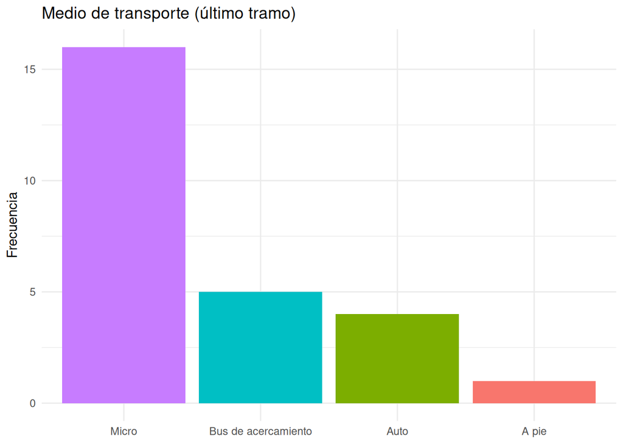

Figura 1: Frecuencia de cada medio de transporte

```r
ggplot(datos, aes(x = fct_infreq(transporte), fill = transporte)) +
  geom_bar() +
  labs(title = "Medio de transporte (último tramo)", x = NULL, y = "Frecuencia") +
  theme_minimal() +
  theme(legend.position = "none")
```

### 3.2 Trabajo remunerado

**Código**

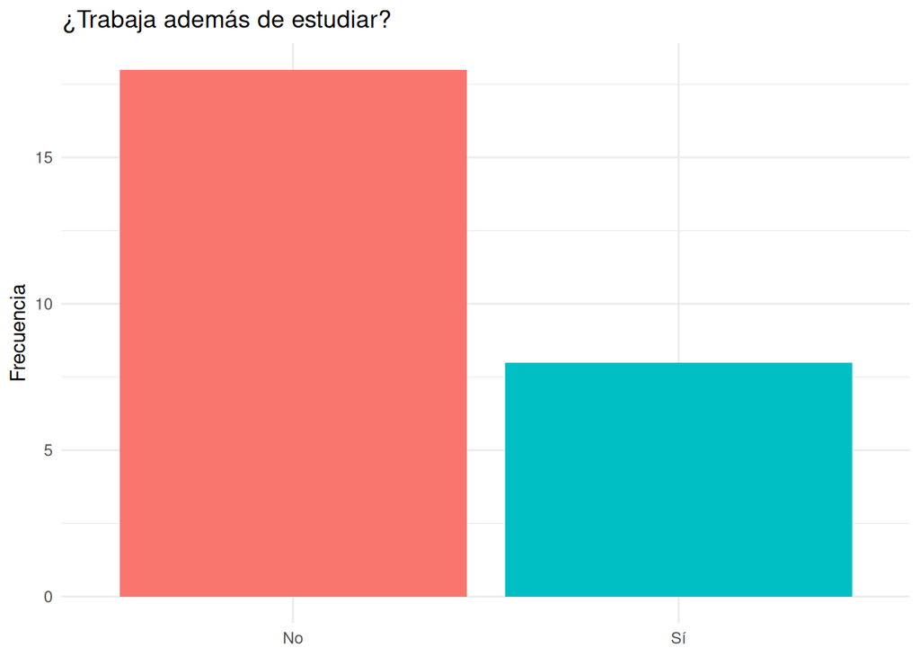

Figura 2: Proporción de estudiantes con trabajo remunerado

```r
ggplot(datos, aes(x = trabaja, fill = trabaja)) +
  geom_bar() +
  labs(title = "¿Trabaja además de estudiar?", x = NULL, y = "Frecuencia") +
  theme_minimal() +
  theme(legend.position = "none")
```

**NotaInterpretación**

## 4 Variables numéricas: distribución univariada

Para cada variable numérica, queremos responder tres preguntas:

1. ¿Dónde está el centro?
2. ¿Qué tan dispersos están los datos?
3. ¿Tiene la distribución alguna forma particular (sesgo, multimodalidad)?

Usamos histogramas y boxplots. Empezamos sin marcas para leer la forma, luego agregamos media y mediana.

### 4.1 Funciones auxiliares

**Código**

```r
# Calcula media y mediana de una variable
marcas <- function(var) {
  datos |>
    summarise(
      media   = mean({{ var }}, na.rm = TRUE),
      mediana = median({{ var }}, na.rm = TRUE)
    )
}

# Histograma sin marcas
hist_simple <- function(var, etiqueta) {
  ggplot(datos, aes(x = {{ var }})) +
    geom_histogram(bins = 10, fill = "steelblue", color = "white") +
    labs(title = etiqueta, x = etiqueta, y = "Frecuencia") +
    theme_minimal()
}

# Histograma con media y mediana
hist_marcas <- function(var, etiqueta) {
  m <- marcas({{ var }})
  ggplot(datos, aes(x = {{ var }})) +
    geom_histogram(bins = 10, fill = "steelblue", color = "white") +
    geom_vline(xintercept = m$media,   color = "red",    linewidth = 1) +
    geom_vline(xintercept = m$mediana, color = "orange", linewidth = 1,
               linetype = "dotted") +
    annotate("text", x = m$media,   y = Inf, label = "media",
             color = "red",    vjust = 2, hjust = -0.1, size = 3.5) +
    annotate("text", x = m$mediana, y = Inf, label = "mediana",
             color = "orange", vjust = 2, hjust = -0.1, size = 3.5) +
    labs(title = etiqueta, x = etiqueta, y = "Frecuencia") +
    theme_minimal()
}
```

### 4.2 Vista general

Un primer vistazo a todas las variables a la vez:

**Código**

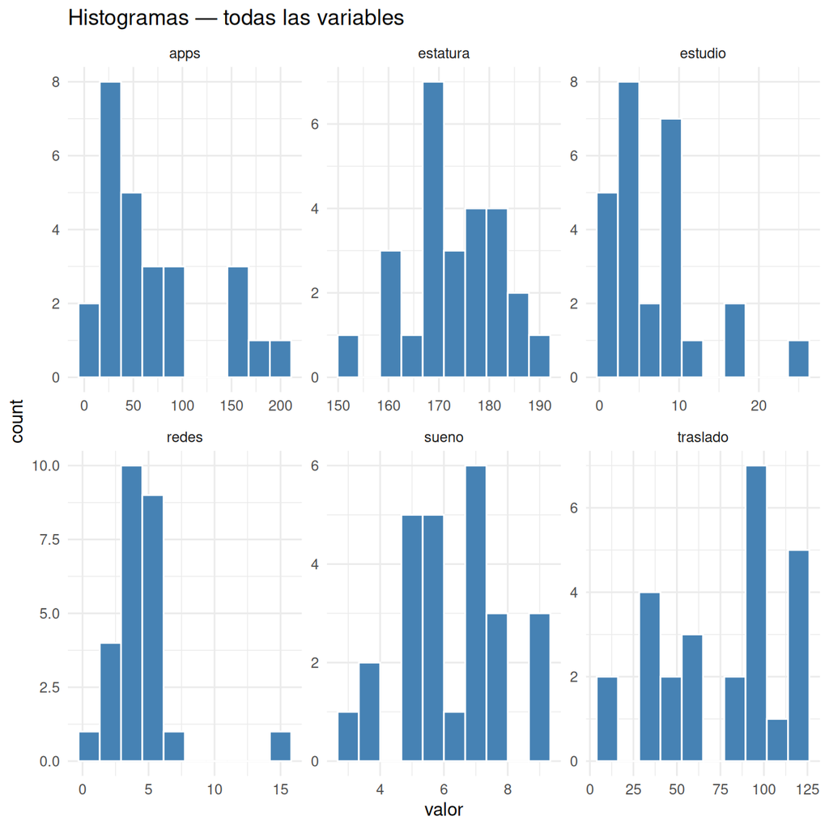

Figura 3: Histogramas de todas las variables numéricas

```r
datos |>
  select(where(is.numeric)) |>
  pivot_longer(everything(), names_to = "variable", values_to = "valor") |>
  ggplot(aes(x = valor)) +
  geom_histogram(bins = 10, fill = "steelblue", color = "white") +
  facet_wrap(~variable, scales = "free") +
  labs(title = "Histogramas — todas las variables") +
  theme_minimal()
```

**NotaInterpretación**

¿Qué variables parecen simétricas? ¿Cuáles tienen sesgo? ¿Hay alguna que llame la atención por su forma?

### 4.3 Análisis variable a variable

#### 4.3.1 Horas de sueño

**Código**

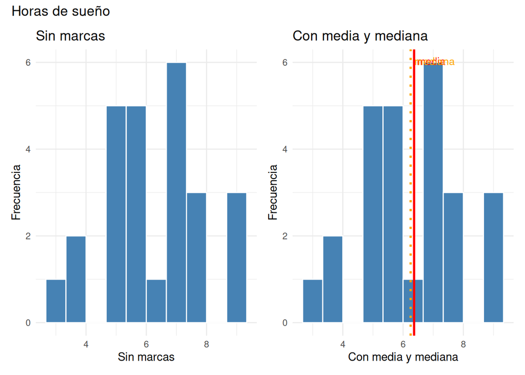

Figura 4: Horas de sueño: sin y con marcas de posición central

```r
p1 <- hist_simple(sueno, "Sin marcas")
p2 <- hist_marcas(sueno, "Con media y mediana")
p1 + p2 + plot_annotation(title = "Horas de sueño")
```

**NotaInterpretación**

¿Coinciden media y mediana? ¿Qué nos dice eso sobre la simetría de la distribución? ¿El valor promedio de sueño es razonable para esta población?

#### 4.3.2 Tiempo de traslado

**Código**

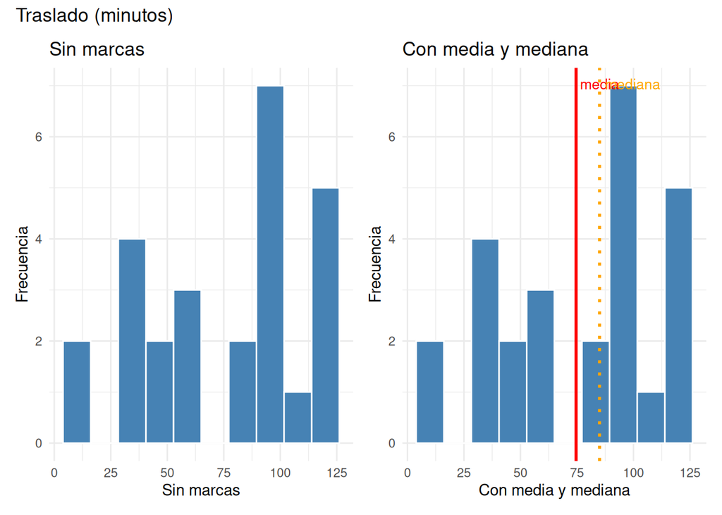

Figura 5: Tiempo de traslado: sin y con marcas de posición central

```r
p3 <- hist_simple(traslado, "Sin marcas")
p4 <- hist_marcas(traslado, "Con media y mediana")
p3 + p4 + plot_annotation(title = "Traslado (minutos)")
```

**NotaInterpretación**

#### 4.3.3 Curva de densidad: estatura

El histograma depende del número de bins. La curva de densidad nos da una visión más suave de la forma de la distribución.

**Código**

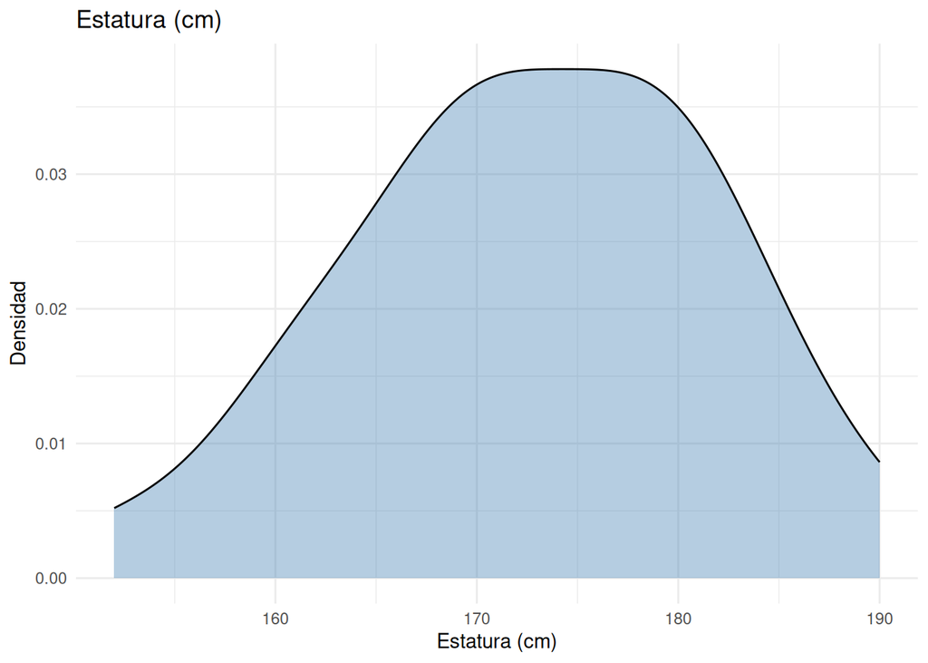

Figura 6: Curva de densidad — estatura

```r
ggplot(datos, aes(x = estatura)) +
  geom_density(fill = "steelblue", alpha = 0.4) +
  labs(title = "Estatura (cm)", x = "Estatura (cm)", y = "Densidad") +
  theme_minimal()
```

**NotaInterpretación**

¿La distribución de estaturas tiene la forma que esperabas? ¿Hay algún patrón llamativo?

## 5 Dispersión y valores atípicos: boxplots

El boxplot muestra cuartiles, rango intercuartílico y valores atípicos de un vistazo. Lo usamos cuando queremos comparar dispersión, no solo centro.

### 5.1 Funciones auxiliares

**Código**

```r
box_simple <- function(var, etiqueta) {
  ggplot(datos, aes(x = {{ var }})) +
    geom_boxplot(fill = "steelblue", width = 0.4) +
    labs(title = etiqueta, x = etiqueta) +
    theme_minimal() +
    theme(axis.text.y = element_blank(), axis.ticks.y = element_blank())
}

box_con_media <- function(var, etiqueta) {
  m <- marcas({{ var }})
  ggplot(datos, aes(x = {{ var }})) +
    geom_boxplot(fill = "steelblue", width = 0.4) +
    annotate("point", y = 0, x = m$media, color = "red", size = 3, shape = 18) +
    labs(title = etiqueta, subtitle = "◆ media", x = etiqueta) +
    theme_minimal() +
    theme(axis.text.y = element_blank(), axis.ticks.y = element_blank())
}
```

### 5.2 Vista general

**Código**

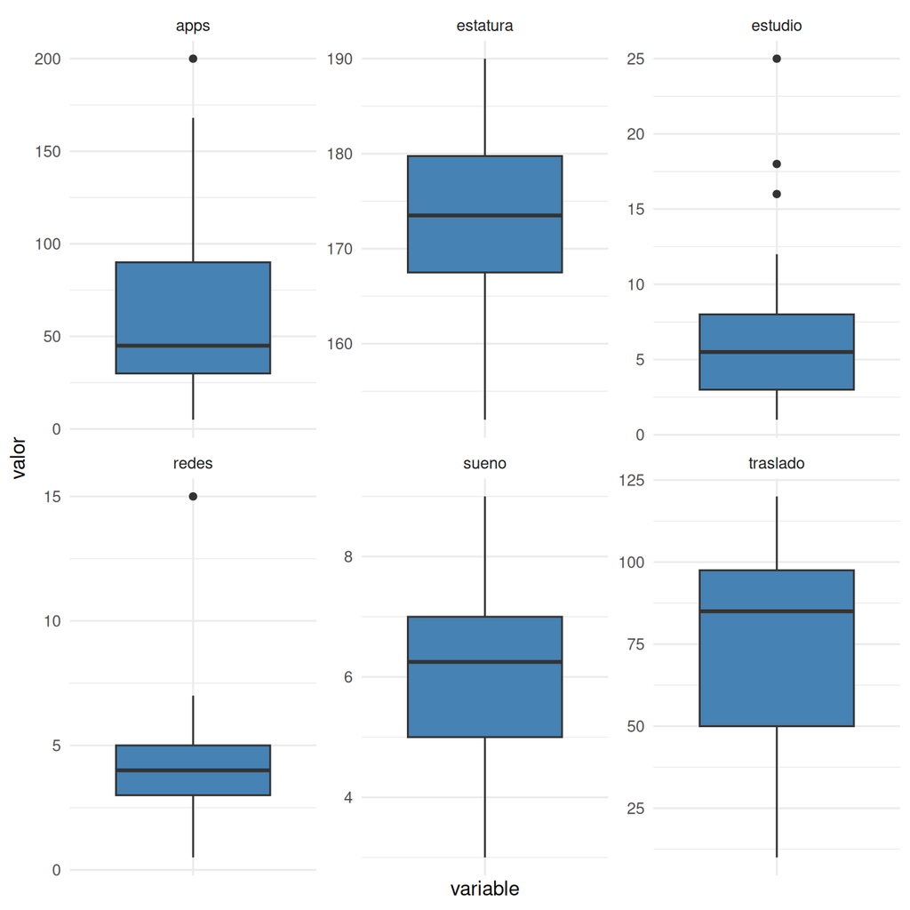

Figura 7: Boxplots de todas las variables numéricas

```r
datos |>
  select(where(is.numeric)) |>
  pivot_longer(everything(), names_to = "variable", values_to = "valor") |>
  ggplot(aes(x = variable, y = valor)) +
  geom_boxplot(fill = "steelblue") +
  facet_wrap(~variable, scales = "free") +
  theme_minimal() +
  theme(axis.text.x = element_blank())
```

### 5.3 Comparación con y sin media

Agregar la media al boxplot nos permite ver si está desplazada respecto a la mediana — lo que indica asimetría.

**Código**

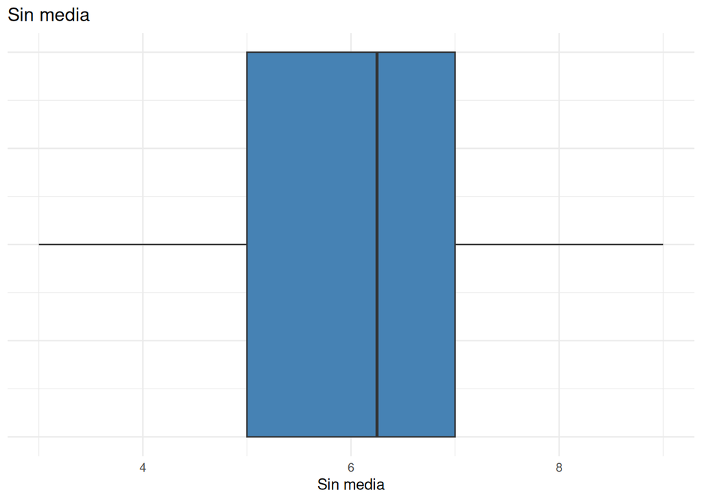

Figura 8: Boxplot de horas de sueño

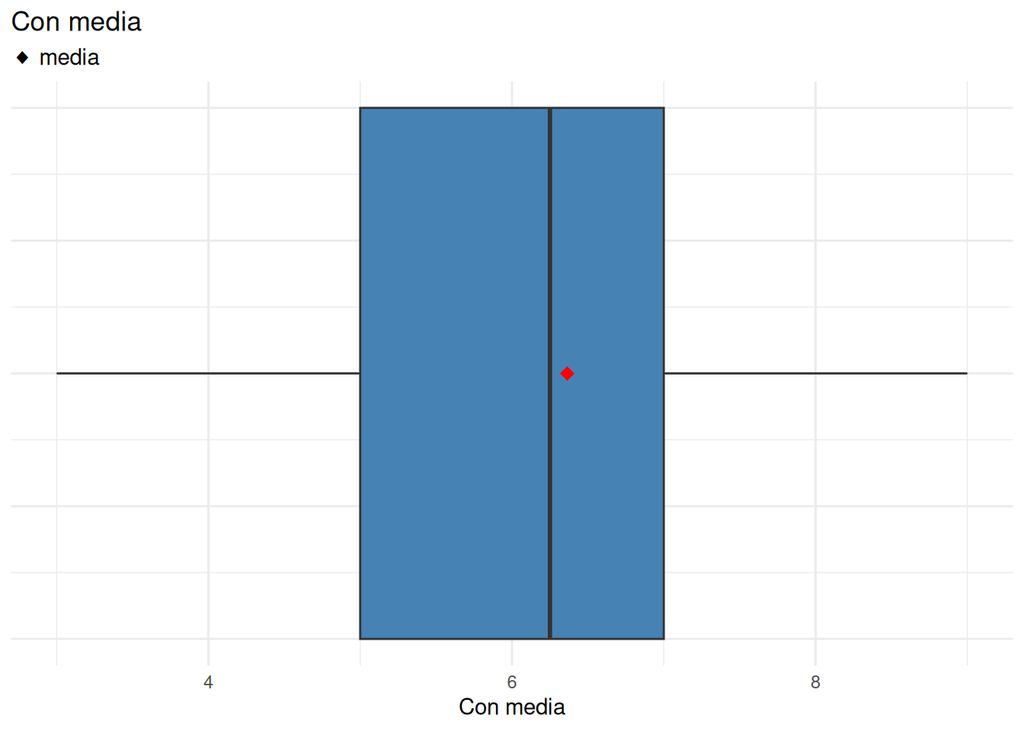

Figura 9: Boxplot de horas de sueño

```r
box_simple(sueno,    "Sin media")  |> print()
box_con_media(sueno, "Con media")  |> print()
```

**NotaInterpretación**

¿Hay valores atípicos? ¿La media está por encima o por debajo de la mediana? ¿Qué implica eso?

## 6 Análisis bivariado: ¿quién duerme más, quién estudia más?

Ahora cruzamos variables para buscar relaciones. La pregunta que hacemos siempre es: **¿importa el grupo al que pertenece una persona?**

### 6.1 Variables numéricas según trabaja/no trabaja

**Código**

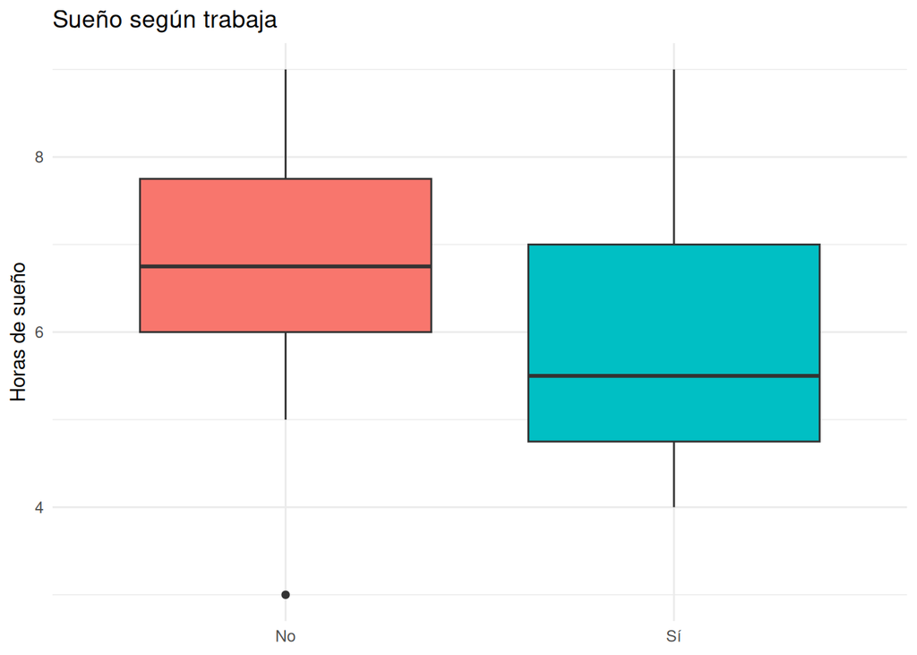

Figura 10: Horas de sueño según trabaja

```r
ggplot(datos, aes(x = trabaja, y = sueno, fill = trabaja)) +
  geom_boxplot() +
  labs(title = "Sueño según trabaja", x = NULL, y = "Horas de sueño") +
  theme_minimal() +
  theme(legend.position = "none")
```

**Código**

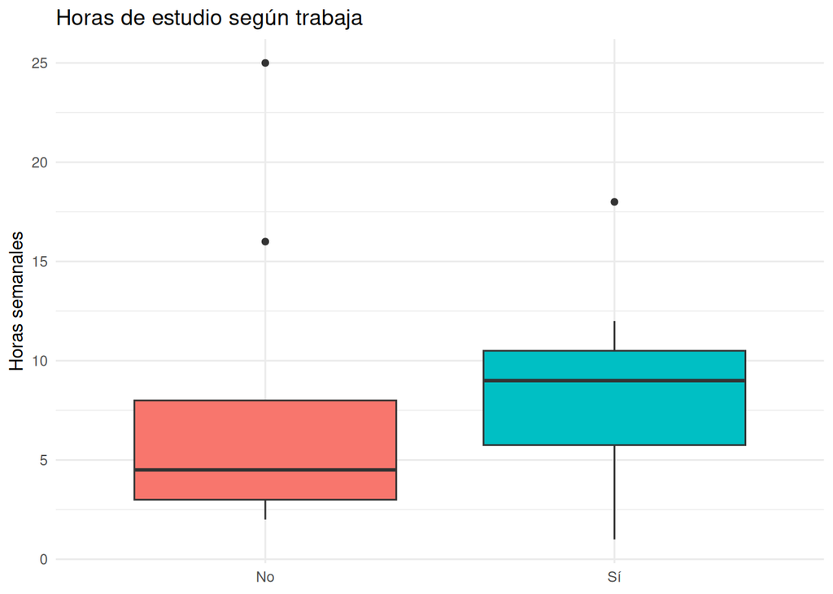

Figura 11: Horas de estudio semanal según trabaja

```r
ggplot(datos, aes(x = trabaja, y = estudio, fill = trabaja)) +
  geom_boxplot() +
  labs(title = "Horas de estudio según trabaja", x = NULL, y = "Horas semanales") +
  theme_minimal() +
  theme(legend.position = "none")
```

**Código**

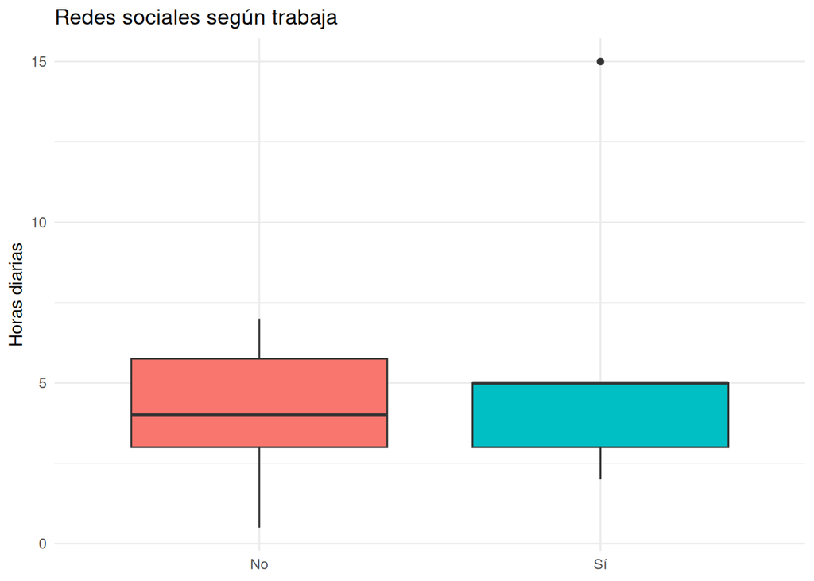

Figura 12: Uso de redes sociales según trabaja

```r
ggplot(datos, aes(x = trabaja, y = redes, fill = trabaja)) +
  geom_boxplot() +
  labs(title = "Redes sociales según trabaja", x = NULL, y = "Horas diarias") +
  theme_minimal() +
  theme(legend.position = "none")
```

**NotaInterpretación**

¿Hay diferencias notables entre quienes trabajan y quienes no? ¿En qué variable se observa la diferencia más grande? ¿Podríamos afirmar que trabajar *causa* esa diferencia?

### 6.2 Traslado según medio de transporte

**Código**

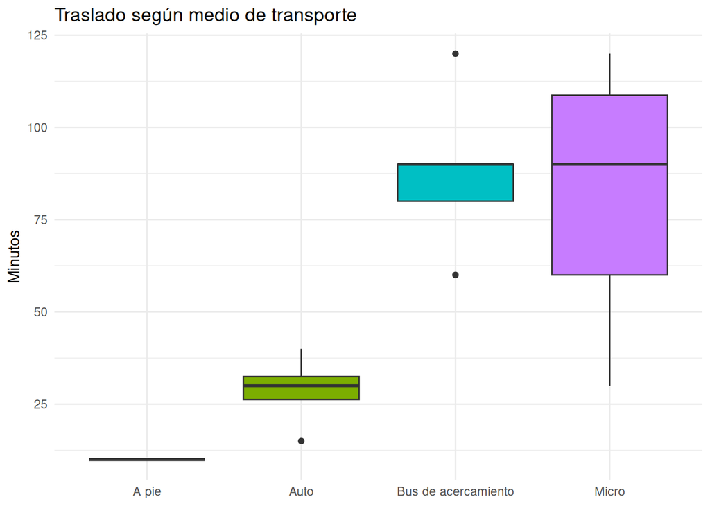

Figura 13: Tiempo de traslado según medio de transporte

```r
ggplot(datos, aes(x = transporte, y = traslado, fill = transporte)) +
  geom_boxplot() +
  labs(title = "Traslado según medio de transporte",
       x = NULL, y = "Minutos") +
  theme_minimal() +
  theme(legend.position = "none")
```

**NotaInterpretación**

## 7 Relaciones entre variables numéricas: diagramas de dispersión

El scatterplot nos permite ver si dos variables numéricas están relacionadas. La línea de tendencia es solo una referencia visual — no es un modelo todavía.

**Código**

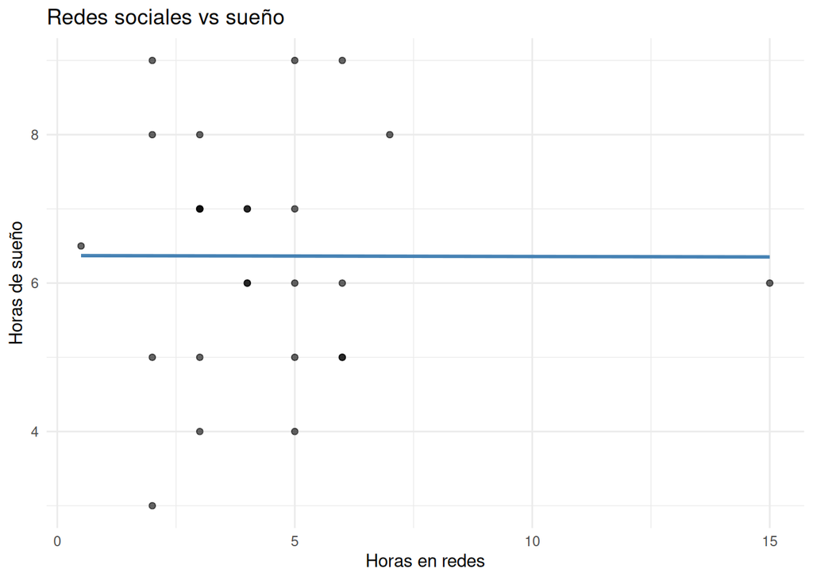

Figura 14: Relación entre uso de redes sociales y horas de sueño

```r
ggplot(datos, aes(x = redes, y = sueno)) +
  geom_point(alpha = 0.6) +
  geom_smooth(method = "lm", se = FALSE, color = "steelblue") +
  labs(title = "Redes sociales vs sueño",
       x = "Horas en redes", y = "Horas de sueño") +
  theme_minimal()
```

**Código**

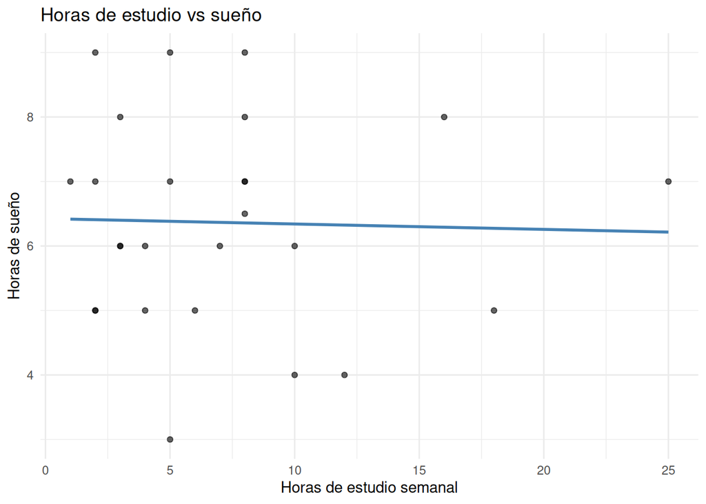

Figura 15: Relación entre horas de estudio y horas de sueño

```r
ggplot(datos, aes(x = estudio, y = sueno)) +
  geom_point(alpha = 0.6) +
  geom_smooth(method = "lm", se = FALSE, color = "steelblue") +
  labs(title = "Horas de estudio vs sueño",
       x = "Horas de estudio semanal", y = "Horas de sueño") +
  theme_minimal()
```

**Código**

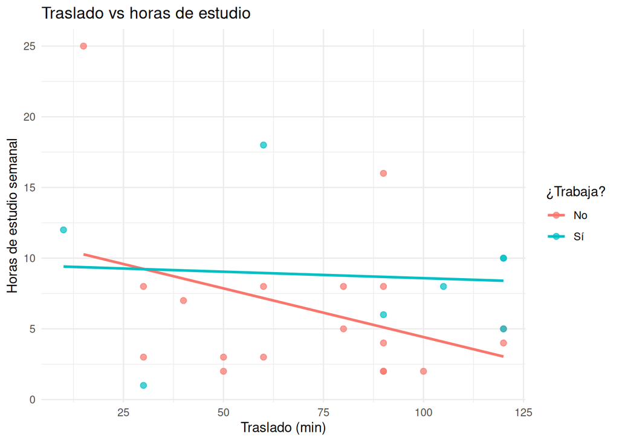

Figura 16: Traslado vs horas de estudio, separado por trabaja

```r
ggplot(datos, aes(x = traslado, y = estudio, color = trabaja)) +
  geom_point(alpha = 0.7, size = 2) +
  geom_smooth(method = "lm", se = FALSE) +
  labs(title = "Traslado vs horas de estudio",
       x = "Traslado (min)", y = "Horas de estudio semanal",
       color = "¿Trabaja?") +
  theme_minimal()
```

**NotaInterpretación**

¿Las relaciones que ves tienen sentido? ¿Cuáles son más fuertes visualmente? ¿Hay alguna que te sorprenda? ¿Correlación implica causalidad?

## 8 Resumen y próximos pasos

**ImportantePara completar en clase**

Resumir los hallazgos principales del análisis:

- Variable con mayor dispersión relativa: …
- Variable con distribución más asimétrica: …
- Relación más interesante encontrada: …
- Pregunta que este análisis *no puede* responder con estos datos: …

El análisis exploratorio es el punto de partida. Los siguientes pasos naturales son cuantificar las relaciones (correlación, regresión) y evaluar si las diferencias observadas entre grupos son estadísticamente significativas (pruebas de hipótesis, ANOVA).